# **Exploring the Best Places to Live After College**

Collaborators: Sadou Sow & Ryan Quiogue

Member 1: Sadou Sow, Contribution: 100%. Member 2: Ryan Quiogue, Contribution: 100%

Because there were only 2 of us, we decided that it would be best to work together in every section so we do not miss anything!

"We, all team members, agree together that the above information is true, and we are confident about our contributions to this submitted project/final tutorial." - Sadou Sow, May 7th

"We, all team members, agree together that the above information is true, and we are confident about our contributions to this submitted project/final tutorial." - Ryan Quiogue, May 7th

Sadou Sow, Ryan Quiogue

In this project, we decided it would be best if we cooperated in every section because that would allow both of us to get our ideas out there. It also allowed us to make sure that nothing was missed when going over the entire project. We worked together on everything, from start to finish, which included many calls, texts, etc. - Sadou

In this project, we decided it would be best if we cooperated in every section because that would allow both of us to get our ideas out there. It also allowed us to make sure that nothing was missed when going over the entire project. We worked together on everything, from start to finish, which included many calls, texts, etc. - Ryan

- The above is repeated because we worked together on everything, as previously mentioned

# **Introduction**

As graduation nears, the big question of where to start our post-college lives becomes a problem that needs a solution. But before we dive into our project, let's take a step back. We're upperclassmen, on the brink of stepping into the real world. So, naturally, we wanted to find a way to help ourselves and our classmates figure out where we might want to go next. We used this question to fuel our search for a dataset.

We want to know for ourseleves, and fellow classmates, how do we determine where is the best place to live for an indiviauls specific needs? We need to find a dataset that allows us to look at a multitude of factors as a whole and specific factors that we find more important than others.

After some searching, we found a dataset that looks at what makes a country happy overall. As we saw looked through the dataset we thought this was the perfect data set to help us make decisions for our future. It has a multitude of factors such as freedom, life expectancy, etc. which people could rank based on which they care more for.

As we're about to take the leap into adulthood we believe finding a place to live becomes super important. This dataset has a lot different information which we could factor in. With all this info, we can ask many questions and since it covers five years, we can even spot any changes over time.

Some questions that we want to delve into are the relationships between the different elements of our data set. Also we want to tackle the question of how do these countries group together differently and how can we use that to affect our decision making?

# **Data Curation**

At this stage of the data science lifecycle for our project we want to grab the data from our dataset and begin the organizing, parsing, and cleaning portion of the lifecycle.

Our search for the perfect data set lead us to a datset of the "World Happiness Report" on the website: (https://www.kaggle.com/datasets/unsdsn/world-happiness?select=2015.csv)

Using this website we are able to download the dataset directly onto our computer and add the file of the specific year you want (or all the years) onto a Google Colab notebook.

Throughout this project we will be using tools such as Google Colab (https://research.google.com/colaboratory/faq.html) and Python (https://docs.python.org/3/)

In order to begin this project we must start just like many other python projects and import our data!

**Imports**

```python
import pandas as pd
import matplotlib.pyplot as plt
import scipy.stats as stats
import seaborn as sns
import numpy as np
from sklearn.cluster import KMeans
```

**Data Processing**

In this project we focus on the information given to us in the year 2019, however, using the dataset we are able to simply change the DataFrame (https://miamioh.edu/centers-institutes/center-for-analytics-data-science/students/coding-tutorials/python/pandas-dataframes.html#:~:text=A%20dataframe%20is%20a%20data,%E2%80%9D%20or%20%E2%80%9Cfood%20group.%E2%80%9D) to be able to work with other years in the dataset

```python
data2019 = pd.read_csv('2019.csv')
```

In this beginning step we are creating a dataframe, in this case called data2019, using all the data from the year 2019 from the dataset mentioned earlier.

This step can be repeated with the other years by putting in the correct name of the csv file inplace of the '2019.csv'

```python
data2019['Score'] = data2019['Score'].astype(float)
data2019['GDP per capita'] = data2019['GDP per capita'].astype(float)
data2019['Social support'] = data2019['Social support'].astype(float)
data2019['Healthy life expectancy'] = data2019['Healthy life expectancy'].astype(float)
data2019['Freedom to make life choices'] = data2019['Freedom to make life choices'].astype(float)
data2019['Generosity'] = data2019['Generosity'].astype(float)
data2019['Perceptions of corruption'] = data2019['Perceptions of corruption'].astype(float)
```

In order for our data to work properly we must make sure to clean our data and change the variable types so there are not error types when trying to look at the differences between two variables.

In this case you will notice that we are changing all of our number variables to floats so in the case we do any kind of math on the column we do not lose any of the information after the decimals if there is any.

```python
duplicates = data2019.duplicated()

for i in duplicates:
  if i == True:
    print(f"Dataset has duplicate values.")
```

```python
missing_data = data2019.isnull().any()

for i in missing_data:
  if i == True:
    print(f"Dataset has duplicate values.")
```

In order to make sure that your data is ready for analysis, you must make sure there is no duplicated or missing data in your dataset. This is very important because missing or duplicated data could skew your entire dataset thus making the answer to whatever question you have incorrect. This could also mess up any tests you may be performing on the dataset so it is important to make sure your dataset has all the appropriate data and no duplicate data.

For more information about duplicate and missing data go here (https://levelup.gitconnected.com/handling-missing-data-and-outliers-in-machine-learning-challenges-and-solutions-c02b1be2ca36)

```python
data2019 = data2019.sort_values(by='Overall rank')
```

After going through the data and making sure there is nothing missing or duplicated, we then want to make sure everything is in order and for us luckily we have a good order to put them in and we cna put them in order of Overall Rank. This allows us to keep or data organized for the tests that we put it through later !

```python
data2019
```

|  | Overall rank | Country or region | Score | GDP per capita | Social support | Healthy life expectancy | Freedom to make life choices | Generosity | Perceptions of corruption |
| --- | --- | --- | --- | --- | --- | --- | --- | --- | --- |
| 0 | 1 | Finland | 7.769 | 1.340 | 1.587 | 0.986 | 0.596 | 0.153 | 0.393 |
| 1 | 2 | Denmark | 7.600 | 1.383 | 1.573 | 0.996 | 0.592 | 0.252 | 0.410 |
| 2 | 3 | Norway | 7.554 | 1.488 | 1.582 | 1.028 | 0.603 | 0.271 | 0.341 |
| 3 | 4 | Iceland | 7.494 | 1.380 | 1.624 | 1.026 | 0.591 | 0.354 | 0.118 |
| 4 | 5 | Netherlands | 7.488 | 1.396 | 1.522 | 0.999 | 0.557 | 0.322 | 0.298 |
| ... | ... | ... | ... | ... | ... | ... | ... | ... | ... |
| 151 | 152 | Rwanda | 3.334 | 0.359 | 0.711 | 0.614 | 0.555 | 0.217 | 0.411 |
| 152 | 153 | Tanzania | 3.231 | 0.476 | 0.885 | 0.499 | 0.417 | 0.276 | 0.147 |
| 153 | 154 | Afghanistan | 3.203 | 0.350 | 0.517 | 0.361 | 0.000 | 0.158 | 0.025 |
| 154 | 155 | Central African Republic | 3.083 | 0.026 | 0.000 | 0.105 | 0.225 | 0.235 | 0.035 |
| 155 | 156 | South Sudan | 2.853 | 0.306 | 0.575 | 0.295 | 0.010 | 0.202 | 0.091 |

156 rows × 9 columns

In this last block of code, we use this in order to see our newly organzied and prased dataset to make sure that everything was done properly.

```python
print('Columns and data types: ')
print(data2019.dtypes)

rows = len(data2019.axes[0])
print('--------------------------------------')
print('Rows: '+ str(rows))
print('--------------------------------------')
print('Checking for missing values: ')
print(data2019.count())
```

```
Columns and data types:
Overall rank                      int64
Country or region                object
Score                           float64
GDP per capita                  float64
Social support                  float64
Healthy life expectancy         float64
Freedom to make life choices    float64
Generosity                      float64
Perceptions of corruption       float64
dtype: object
--------------------------------------
Rows: 156
--------------------------------------
Checking for missing values:
Overall rank                    156
Country or region               156
Score                           156
GDP per capita                  156
Social support                  156
Healthy life expectancy         156
Freedom to make life choices    156
Generosity                      156
Perceptions of corruption       156
dtype: int64
```

Here we can see all of our data types. We also have printed the rows. We check the rows to see if there is any missing data/ duplicate data that we have to handle. Luckily there is no missing/ duplicated data so we can begin to analyze our data and conduct tests on it.

# **Exploratory Analysis**

The exploratory analysis stage of the data science life cycle si the part where we look through our data using graphs and plot it in order to see if there are any relationships between variables.

This is important to us becasue in the case that someone has 2 variables that they find very important we could plot these two together to see if there is a relationship between the two and if so which place would satisify both variables enough for said person to move there.

# **Test 1**

In the future we know that there are many things that go into where we choose where we want to live. One thing that we find very important is a healthy life expentancy because life expectancy is a topic that is commonly talked about in the realm of happiness as it gives us more time to live out our life and experience what the world has to offer. Another topic that is important is freedom because the values of freedom and liberty has been instilled in us since we were young growing up in the United States

Espsically going to college in America we have a decent healthy life expectany and a lot of freedom to make choices.

In this test we want to see if there is any correlation between the two

```python
coef, p_val = stats.pearsonr(data2019['Healthy life expectancy'], data2019['Freedom to make life choices'])

print(f"Pearson Correlation Coefficient: {coef:.2f}")
print(f"P-value: {p_val}")
```

```
Pearson Correlation Coefficient: 0.39
P-value: 4.699404047299066e-07
```

In our scenario we recvied a coefficient of 0.39 which is close to 0 but also a good amount away for us to consider its correlation in the long run.

The p value will tell us the signiciance of the correlation coefficiet and will tell us if the null hypothesis is true. Typically a small p value tells us that the corrleation coefficient is true and in this case we recivied a small p value

Using this information we can make a graph to better visualize the correlation.

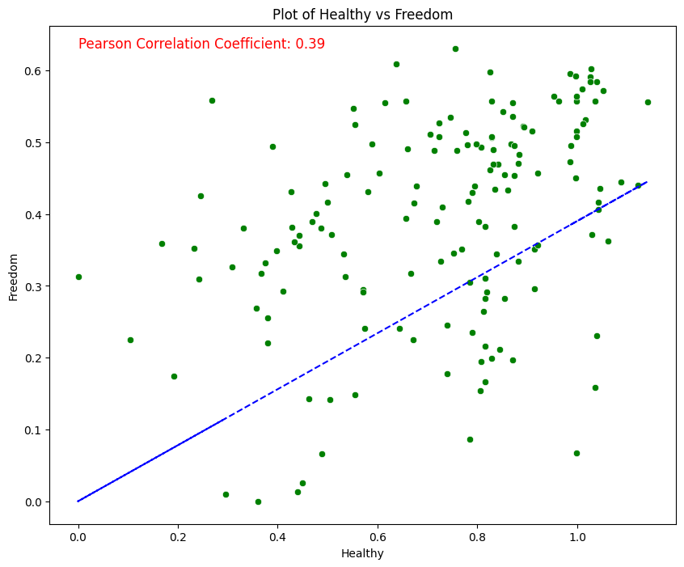

```python
plt.figure(figsize=(10,8))
sns.scatterplot(x='Healthy life expectancy', y='Freedom to make life choices', data=data2019, color='green')
plt.title('Plot of Healthy vs Freedom')
plt.xlabel('Healthy')
plt.ylabel('Freedom')
plt.text(data2019['Healthy life expectancy'].min(), data2019['Freedom to make life choices'].max(),
         f'Pearson Correlation Coefficient: {coef:.2f}', fontsize=12, color='red')
plt.plot(data2019['Healthy life expectancy'], coef * data2019['Healthy life expectancy'], color='blue', linestyle='--')
plt.show()
```

There are are some outliers that have a very healthy life expectancy but very little freedom and the opposite is true with some having higher freedom but lower healthy life expectancy.

While there is not a huge correlation between the two I think it is important to keep this in mind because the correlation is in fact in the positive direction. So in the end we believe this is something that this relationship between freedom and health is essential to consider

This kind of test is very important to test for becasue in the scenario where soemone wants to have the best of both worlds we need to see if we can find a place that has the most of both variables. In the scenario above we saw that there is not too much of a correlation we could use the graph to pinpoint where the person might want to look when deciding where to stay based on where both of the variables are the highest

**Test 2**

[figure not shown]

```python
num_cols = len(data2019.columns)
num_rows = num_cols // 3 + (1 if num_cols % 3 > 0 else 0)
fig, axes = plt.subplots(num_rows, 3, figsize=(15, num_rows * 5))
axes = axes.flatten()
```

In this block of code we are trying to determine the number of subplots to make in our overall grid. We are trying to determine the total number of rows we could have if we have 3 columns per row. This is important because due to the number of columns we have total in our 2019 dataset we want to see how everything is skewed.

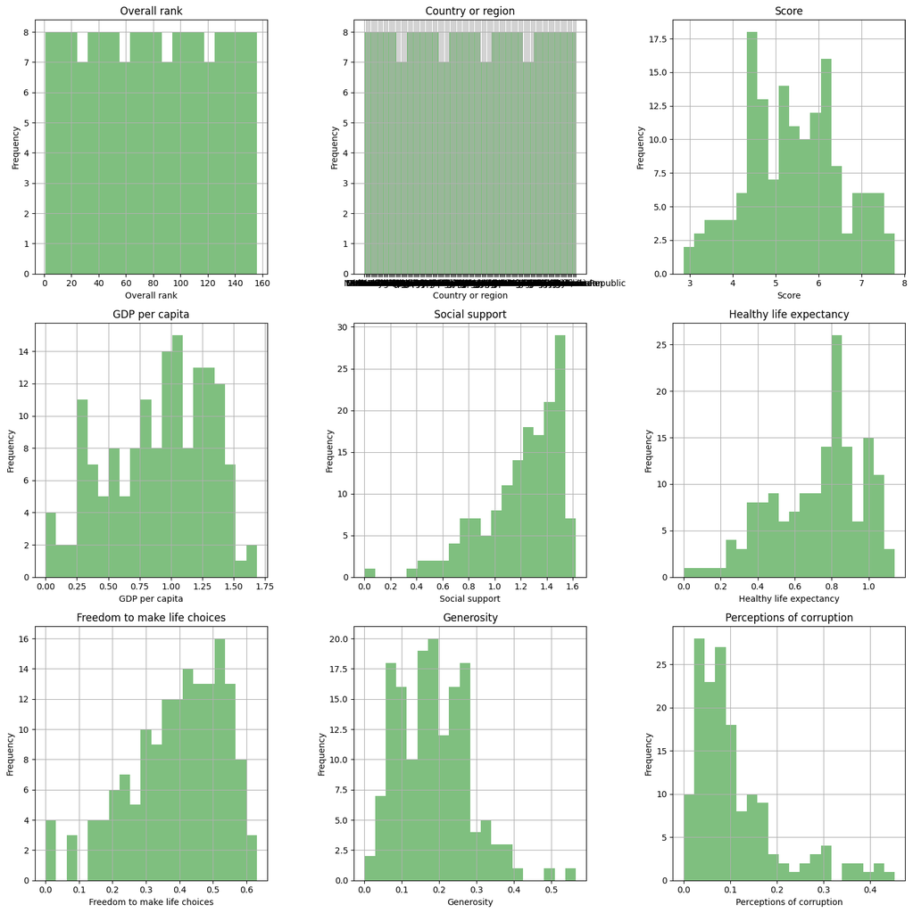

```python
num_cols = len(data2019.columns)
num_rows = num_cols // 3 + (1 if num_cols % 3 > 0 else 0)
fig, axes = plt.subplots(num_rows, 3, figsize=(15, num_rows * 5))
axes = axes.flatten()

for i, col in enumerate(data2019.columns):
    ax = axes[i]
    data2019[col].hist(ax=ax, bins=20, color='green', alpha=0.5)
    ax.set_title(f'{col}')
    ax.set_xlabel(col)
    ax.set_ylabel('Frequency')

for i in range(num_cols, num_rows * 3):
  fig.delaxes(axes[i])

plt.tight_layout()
plt.show()
```

Generosity: One thing that was interesting to observe was the generosity distribution. It heavily favored the lower values. This is surprising to see that not many countries are high in this stat. It might speak to how much it factors into the happiness score

Healthy life expectancy: In general we see that the healthy life expectancy is on the higher end. This makes sense as we see the world as a collective has been improving life quality with things like medicine and science

Freedom to make life choices: This is another category that is on the higher end. This is also explained by the strives we are making as a global society in the way of more freedoms for people.

**Test 3**

We want to test to see if the average happiness score of the world is greater than 5. We are testing to see if the world is generally happier than it is unhappy

H0: μ = 5

HA: μ > 5

α = 0.05

```
The mean happiness score: 5.407096153846155
n = 156
t_stat = 4.567908160107777
p-value = 4.994563929800232e-06
```

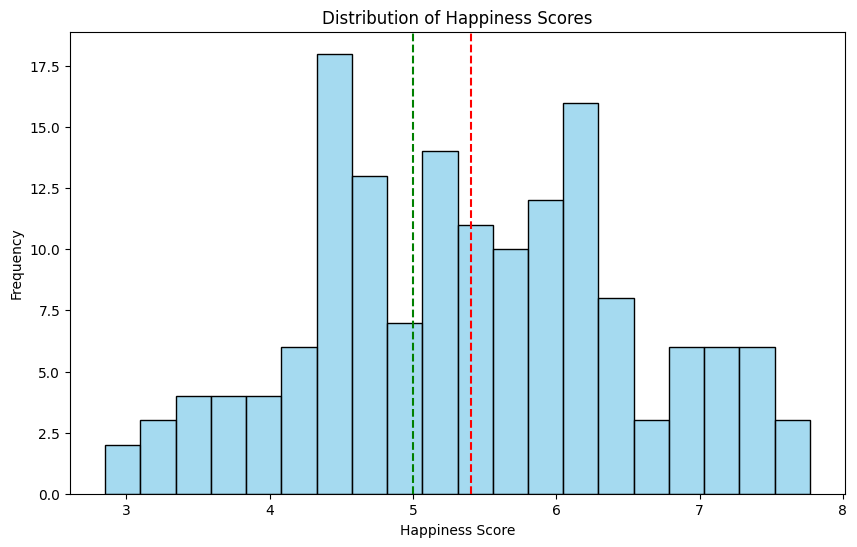

```
We reject the null hypothesis. We have enough evidence to say that mean is greater than 5
```

```python
happinessScores = data2019.Score
mu = 5
alpha = 0.05

print("The mean happiness score: " + str(happinessScores.mean()))
print("n = " + str(len(happinessScores)))

t_stat, p_value = stats.ttest_1samp(happinessScores, mu, alternative='greater')
print("t_stat = " + str(t_stat))
print("p-value = " + str(p_value))

plt.figure(figsize=(10, 6))
sns.histplot(happinessScores, bins=20, color='skyblue')
plt.axvline(x=happinessScores.mean(), color='red', linestyle='--', label='Mean')
plt.axvline(mu, color='green', linestyle='--', label='Mu')
plt.xlabel('Happiness Score')
plt.ylabel('Frequency')
plt.title('Distribution of Happiness Scores')
plt.show()

if p_value < alpha:
    print("We reject the null hypothesis. We have enough evidence to say that mean is greater than 5")
else:
    print("We fail to reject the null hypothesis. We do not have the evidence to say that the mean is greater than 5")
```

Based on the hypothesis test we can see that the average happiness scores are in fact greater than 5. This means that the on average the world is happier than unhappier. The p-value was very low so there is a very low probabability that we falsely rejected the null

Despite being on the simpler side, this is a very important factor to consider because not everyone has the luxury to choose where they live in the future. Some people may end up in places they do not want to be and may worry about how their lives might be in those areas.

We want to assure our classmates that no matter where they are they are most likely going to end up in a good position due to our findings that the world's average happiness is on the higher side. This means despite where we, or our class mates may end up, on average we will be happy !

# **Primary Analysis**

In this section, the technology of machine learning will be used in order to further explore this data and the specific characteristics of the set. Machine learning is a subfield of artificial intelligence (AI) that focuses on the development of algorithms and statistical models that enable computer systems to learn and improve their performance on a specific task or problem without being explicitly programmed. Due to the restrictions of our data set, we will be using unsupervised learning in order to find clusterings of data. Unsupervised learning is a subset of machine learning in which the input data does not have any labels. Instead, it finds specific groupings or "Clusters"

In this we will specifially using K-means clustering. It uses clusters and centroids in order to find groupings. A cluster is a set of instances with similar characteristics. A "centroid" is a point that represents the center of each cluster

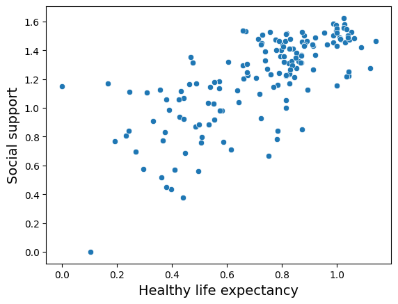

```python
clustering_df = data2019.filter(['Healthy life expectancy', 'Social support'], axis = 1)
p = sns.scatterplot(data=data2019, x='Healthy life expectancy', y='Social support')
p.set_xlabel('Healthy life expectancy', fontsize=14)
p.set_ylabel('Social support', fontsize=14)
```

Here in this first section of code we are starting to visualize what our data looks like and maybe understand what kind of clusters there are.

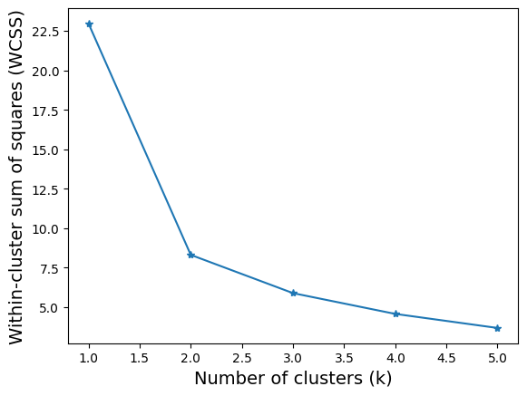

```python
WCSS = []
k = [1, 2, 3, 4, 5]
for j in k:
    kmModel = KMeans(n_clusters=j)
    kmModel = kmModel.fit(clustering_df)
    WCSS.append(kmModel.inertia_)

ax = plt.figure().gca()
plt.plot(k, WCSS, '*-')
plt.xlabel('Number of clusters (k)', fontsize=14)
plt.ylabel('Within-cluster sum of squares (WCSS)', fontsize=14)
```

With this analysis we are looking into the relationship between healthy life expectancy and social support and see if we can find any groups that they have within them

```python
kmModel = KMeans(n_clusters = 2)

kmModel = kmModel.fit(clustering_df)

centroids = kmModel.cluster_centers_
```

Here we are setting up the model to fit the data set. This is where we train and obtain the centroids.

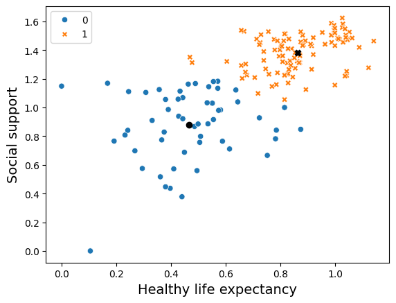

```python
clusters = kmModel.fit_predict(clustering_df[['Healthy life expectancy', 'Social support']])

p = sns.scatterplot(
    data=clustering_df, x='Healthy life expectancy', y='Social support', hue=clusters, style=clusters
)
p.set_xlabel('Healthy life expectancy', fontsize=14)
p.set_ylabel('Social support', fontsize=14)

# Add centroid for cluster 0
plt.scatter(x=centroids[0, 0], y=centroids[0, 1], c='black')

# Add centroid for cluster 1
plt.scatter(x=centroids[1, 0], y=centroids[1, 1], c='black', marker='X')
```

Here we have two separate groups shown in orange and blue. We have each centroid also shown. With this we gain insight on the different groupings of the data set with it looking like it is split between the top right quadrant and then the bottom left quadrant. These two factors: Healthy life expectancy and social support are very important and we ideally want a country that can balance both. With these clusterings we can see that there is a clear distinction between the countries with high life expectancy and social support and the ones without.

We will now be doing something similar but with 3 variables instead of two

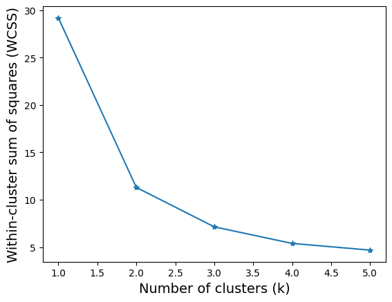

```python
clustered_df_3d = data2019.filter(['GDP per capita', 'Freedom to make life choices', 'Generosity'], axis = 1)
WCSS = []
k = [1, 2, 3, 4, 5]
for j in k:
    kmModel = KMeans(n_clusters=j)
    kmModel = kmModel.fit(clustered_df_3d)
    WCSS.append(kmModel.inertia_)

ax = plt.figure().gca()
plt.plot(k, WCSS, '*-')
plt.xlabel('Number of clusters (k)', fontsize=14)
plt.ylabel('Within-cluster sum of squares (WCSS)', fontsize=14)
```

Here we have shown that the optimal amount of clusters is two so we will be using a kmeans with k being set to 2

```python
kmModel_3d = KMeans(n_clusters = 2)
kmeans_3d = kmModel_3d.fit_predict(clustering_df)

centroids = kmModel_3d.cluster_centers_
```

```python
clustered_df_3d['cluster'] = kmeans_3d

cluster1 = clustered_df_3d[clustered_df_3d.cluster==0]
cluster2 = clustered_df_3d[clustered_df_3d.cluster == 1]
```

Here we split up the clusters into two separate data frames so we can plot them

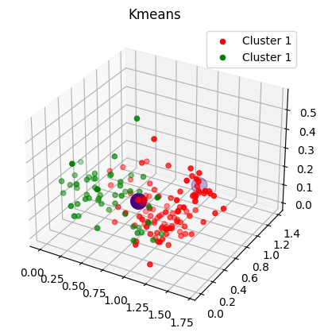

```python
kplot = plt.axes(projection='3d')

kplot.scatter(cluster1['GDP per capita'], cluster1['Freedom to make life choices'], cluster1['Generosity'], c='red', label = 'Cluster 1')
kplot.scatter(cluster2['GDP per capita'], cluster2['Freedom to make life choices'], cluster2['Generosity'], c='green', label = 'Cluster 1')

plt.scatter(kmModel_3d.cluster_centers_[:,0], kmModel_3d.cluster_centers_[:,1], color = 'indigo', s = 200)
plt.legend()
plt.title("Kmeans")
plt.show()
```

With both of these models we can figure out the different groups that our prospective country might belong to. This can help us narrow down the search as looking at all of the data at once can be challenging. We can narrow our search based on being in a favorable cluster.

Using these models we are able to take in specific characteristics that are favorable to a person and help them narrow down their search of where they would want to live. This answers our question of how to determine where to live !

# **Conclusions**

Throughout this project, we set out on a mission to create something that could help us find the best place to live post college. We made it our mission to help ourselves and our peers to make informed decisions about our future. As many of us approach graduation we know this question looms and a solution is needed very soon.

To begin our project we searched for a dataset that takes in a multitude of variables and factors them in order to find the best place to live. After some searching we eventually landed on the "World Happiness Report" and it helped us start our project.

Throughout this project we used tools such as Google Colab and Python in order to organize, parse, an clean data in order to prepare it for anaylsis. Using this data we wanted to find patterns/ relationships in the data to help us in our decision making process.

During our exploratory analysis phase, we devled into the relationships of different variables to see if any corrlations exist. We also conducted many statistical tests in order to verify our findings to make sure our conclusions are solid.

Following the exploratory analysis phase, we used machine learning, in our case K-means clustering, to identify distinct clusters based on characteristics. These characterstics could change depending on the person so K-means clustering could take in multiple variables and give a person a group of the best places based on their chosen characteristics

In the end, we learned that in order to make a decision such as choosing a place to live, there are many factors that could be at play. Some people may want the the most amount of freedom and not care much about anything else. Some people may want the best of everything. In order to determine which place woukld be the best for you, you want to determine which characteristics are the most important to you and find a place that adheres to those characteristics without having to sacrifice anything.